# Scripts for Isoscapes analysis for the Boardman/Ottaway River

Selina Al-Nazzal, Greg Jacobs

4 April 2025

# Data import and managment

```r
library(tidyverse)
library(remotes)
library(lmerTest)
library(emmeans)
## Install the latest version of SSN2 from github
remotes::install_github("USEPA/SSN2", ref="develop", dependencies=TRUE)
```

```r
library(SSN2)
library(ggplot2)
library(sf) # handle geospatial data
library(patchwork) # nice multi-panel plot arranging
library(png)
# streams <- st_read("streamdata/streams.shp") %>%
#   select(COMID, geometry)
# streams500 <- st_read("streamdata/pred_streams500.shp") %>%
#   filter(COMID%in%streams$COMID) %>%
#   select(predID500, COMID, geometry)
# borpred <- st_read("streamdata/pred_bor500.shp") %>%
#   select(COMID, geometry)
# function to scale variables given mu and sd (intended for preds tables)
scale_fun <- function(df, df_mu, df_sd){
  df<- df %>%
  mutate(z_lnQ5=(lnQ5-df_mu$lnQ5)/df_sd$lnQ5,
         z_Q5=(Q5-df_mu$Q5)/df_sd$Q5,
         z_p_FstCatR=(p_FstCatR-df_mu$p_FstCatR)/df_sd$p_FstCatR,
         z_p_FstWsR=(p_FstWsR-df_mu$p_FstWsR)/df_sd$p_FstWsR,
         z_p_FstWs=(p_FstWs-df_mu$p_FstWs)/df_sd$p_FstWs,
         z_p_WetCatR=(p_WetCatR-df_mu$p_WetCatR)/df_sd$p_WetCatR,
         z_p_WetWs=(p_WetWs-df_mu$p_WetWs)/df_sd$p_WetWs,
         z_p_DecidWsR=(p_DecidWsR-df_mu$p_DecidWsR)/df_sd$p_DecidWsR,
         z_p_CropWs=(p_CropWs-df_mu$p_CropWs)/df_sd$p_CropWs,
         z_p_ImpCat=(p_ImpCat-df_mu$p_ImpCat)/df_sd$p_ImpCat,
         z_PopCat_SKm=(PopCat_SKm-df_mu$PopCat_SKm)/df_sd$PopCat_SKm,
         z_BFICat=(BFICat-df_mu$BFICat)/df_sd$BFICat)
  return(df)
}
```

# Georeferenced Isotope Data

## Biofilm

```r
lsn.path.biof <- "./lsn.biof/BORbiof.ssn"
# import the biofilm SSN data object
biof_ssn <- ssn_import(path=lsn.path.biof, predpts=c("pred500", "predNHD"),
  overwrite=TRUE)
# center and scale covariates
df_mu <- biof_ssn$obs %>% select(SiteID, Q5:BFICat) %>% distinct() %>%
  summarize(across(Q5:BFICat, mean))
df_sd <- biof_ssn$obs %>% select(SiteID, Q5:BFICat) %>% distinct() %>%
  summarize(across(Q5:BFICat, sd))
biof_ssn$obs <- biof_ssn$obs %>%
  mutate(across(Q5:BFICat, scale, .names="z_{.col}"))
biof_ssn$preds$pred500 <- scale_fun(biof_ssn$preds$pred500,
                                                  df_mu, df_sd)
biof_ssn$preds$predNHD <- scale_fun(biof_ssn$preds$predNHD,
                                                  df_mu, df_sd)
## create distance matrices needed for spatial statistical modeling
ssn_create_distmat(ssn.object=biof_ssn, predpts=c("pred500", "predNHD"),
  among_predpts=TRUE, overwrite=TRUE)
```

## Heptageniidae

```r
lsn.path.hept <- "./lsn.hept/BORhept.ssn"
# import the heptilm SSN data object
hept_ssn <- ssn_import(path=lsn.path.hept, predpts=c("pred500", "predNHD"),
  overwrite=TRUE)
# center and scale covariates
hept_ssn$obs <- hept_ssn$obs %>%
  mutate(across(Q5:BFICat, scale, .names="z_{.col}"))
hept_ssn$preds$pred500 <- scale_fun(hept_ssn$preds$pred500,
                                                  df_mu, df_sd)
hept_ssn$preds$predNHD <- scale_fun(hept_ssn$preds$predNHD,
                                                  df_mu, df_sd)
## create distance matrices needed for spatial statistical modeling
ssn_create_distmat(ssn.object=hept_ssn, predpts=c("pred500", "predNHD"),
  among_predpts=TRUE, overwrite=TRUE)
```

## Amphipoda

```r
lsn.path.amph <- "./lsn.amph/BORamph.ssn"
# import the amphilm SSN data object
amph_ssn <- ssn_import(path=lsn.path.amph, predpts=c("pred500", "predNHD"),
  overwrite=TRUE)
# center and scale covariates
amph_ssn$obs <- amph_ssn$obs %>%
  mutate(across(Q5:BFICat, scale, .names="z_{.col}"))
amph_ssn$preds$pred500 <- scale_fun(amph_ssn$preds$pred500,
                                                  df_mu, df_sd)
amph_ssn$preds$predNHD <- scale_fun(amph_ssn$preds$predNHD,
                                                  df_mu, df_sd)
## create distance matrices needed for spatial statistical modeling
ssn_create_distmat(ssn.object=amph_ssn, predpts=c("pred500", "predNHD"),
  among_predpts=TRUE, overwrite=TRUE)
```

## Hydrobiidae

```r
lsn.path.muds <- "./lsn.muds/BORmuds.ssn"
# import the mudsilm SSN data object
muds_ssn <- ssn_import(path=lsn.path.muds, predpts=c("pred500", "predNHD"),
  overwrite=TRUE)
# center and scale covariates
muds_ssn$obs <- muds_ssn$obs %>%
  mutate(across(Q5:BFICat, scale, .names="z_{.col}"))
muds_ssn$preds$pred500 <- scale_fun(muds_ssn$preds$pred500,
                                                  df_mu, df_sd)
muds_ssn$preds$predNHD <- scale_fun(muds_ssn$preds$predNHD,
                                                  df_mu, df_sd)
## create distance matrices needed for spatial statistical modeling
ssn_create_distmat(ssn.object=muds_ssn, predpts=c("pred500", "predNHD"),
  among_predpts=TRUE, overwrite=TRUE)
```

## Summaries and comparisons

```r
rbind(df_mu, df_sd) %>% st_drop_geometry() %>% mutate(metric=c("mean", "sd"))
```

```
##         Q5      lnQ5 p_FstCatR p_FstWsR  p_FstWs p_WetCatR  p_WetWs p_DecidWsR
## 1 2.566439 0.2411581  30.02200 31.02300 45.56000  53.84333 14.25667  25.243000
## 2 2.901931 1.2900645  17.46078 10.32849 11.79829  16.22786  4.84224   9.901593
##   p_CropWs p_ImpCat PopCat_SKm     BFICat metric
## 1 7.494333 4.254000   53.16521 85.7083994   mean
## 2 6.724068 7.883328   88.09844  0.8706255     sd
```

```r
# overall sample sizes
bind_rows(
biof_ssn$obs %>% summarize(nd13C=sum(!is.na(d13C)), nd15N=sum(!is.na(d15N))) %>% mutate(taxon='Biofilm'),
hept_ssn$obs %>% summarize(taxon=first(Family), FFG=first(Feeding_group), nd13C=sum(!is.na(d13C)), nd15N=sum(!is.na(d15N)), nd34S=sum(!is.na(d34S))),
amph_ssn$obs %>% summarize(taxon=first(Family), FFG=first(Feeding_group), nd13C=sum(!is.na(d13C)), nd15N=sum(!is.na(d15N)), nd34S=sum(!is.na(d34S))),
muds_ssn$obs %>% summarize(taxon=first(Family), FFG=first(Feeding_group), nd13C=sum(!is.na(d13C)), nd15N=sum(!is.na(d15N)), nd34S=sum(!is.na(d34S)))
) %>% st_drop_geometry() %>% select(taxon, FFG, nd13C, nd15N, nd34S)
```

```
##            taxon                 FFG nd13C nd15N nd34S
## 1        Biofilm                <NA>   109   109    NA
## 2  Heptageniidae             Scraper    69    69    20
## 3 Dogielinotidae Collecter/gatherers    21    21     5
## 4    Hydrobiidae Collecter/gatherers    32    32     7
```

Compare average isotopic values by taxon using repeated measures ANOVA (replication at the site level). The repeated measures anova was fit with lme4::lmer()

### d13C

Inference of ANOVA using Kenward-Roger degrees of freedom adjustment for random effect of site.

```r
anovadat <- do.call(bind_rows, list(st_drop_geometry(biof_ssn$obs),
                              st_drop_geometry(hept_ssn$obs),
                              st_drop_geometry(amph_ssn$obs),
                              st_drop_geometry(muds_ssn$obs))) %>%
  mutate(Taxon=factor(ifelse(is.na(Substrate), Family, Substrate),
                      levels=c("Hester-Dendy", "Rock", "Heptageniidae",
                               "Dogielinotidae", "Hydrobiidae")))
anova13C <- lmer(d13C ~ Taxon + (1|SiteID), data=anovadat)
anova(anova13C, ddf="Kenward-Roger")
```

```
## Type III Analysis of Variance Table with Kenward-Roger's method
##       Sum Sq Mean Sq NumDF  DenDF F value    Pr(>F)
## Taxon 3551.8  887.95     4 216.09  242.29 < 2.2e-16 ***
## ---
## Signif. codes:  0 '***' 0.001 '**' 0.01 '*' 0.05 '.' 0.1 ' ' 1
```

Least square means and pairwise differences among taxa using Tukey post-hoc comparisons with kenward-Roger degrees of freedom adjustment.

```r
emm13C <- emmeans(anova13C, list(pairwise ~ Taxon), adjust="tukey")
emm13C
```

```
## $`emmeans of Taxon`
##  Taxon          emmean    SE    df lower.CL upper.CL
##  Hester-Dendy    -25.9 0.276  63.1    -26.5    -25.4
##  Rock            -21.1 0.452 196.9    -22.0    -20.2
##  Heptageniidae   -33.4 0.302  79.4    -34.0    -32.8
##  Dogielinotidae  -30.4 0.505 176.5    -31.4    -29.4
##  Hydrobiidae     -31.6 0.415 148.1    -32.5    -30.8
##
## Degrees-of-freedom method: kenward-roger
## Confidence level used: 0.95
##
## $`pairwise differences of Taxon`
##  1                               estimate    SE  df t.ratio p.value
##  (Hester-Dendy) - Rock              -4.87 0.463 202 -10.515  <.0001
##  (Hester-Dendy) - Heptageniidae      7.47 0.317 209  23.535  <.0001
##  (Hester-Dendy) - Dogielinotidae     4.41 0.513 224   8.605  <.0001
##  (Hester-Dendy) - Hydrobiidae        5.69 0.424 219  13.416  <.0001
##  Rock - Heptageniidae               12.34 0.479 206  25.744  <.0001
##  Rock - Dogielinotidae               9.28 0.632 222  14.689  <.0001
##  Rock - Hydrobiidae                 10.56 0.566 218  18.667  <.0001
##  Heptageniidae - Dogielinotidae     -3.06 0.537 226  -5.699  <.0001
##  Heptageniidae - Hydrobiidae        -1.78 0.440 220  -4.039  0.0007
##  Dogielinotidae - Hydrobiidae        1.28 0.615 226   2.080  0.2321
##
## Degrees-of-freedom method: kenward-roger
## P value adjustment: tukey method for comparing a family of 5 estimates
```

### d15N

Inference of ANOVA using Kenward-Roger degrees of freedom adjustment for random effect of site.

```r
anova15N <- lmer(d15N ~ Taxon + (1|SiteID), data=anovadat)
anova(anova15N, ddf="Kenward-Roger")
```

```
## Type III Analysis of Variance Table with Kenward-Roger's method
##       Sum Sq Mean Sq NumDF  DenDF F value    Pr(>F)
## Taxon 347.33  86.834     4 205.65   190.8 < 2.2e-16 ***
## ---
## Signif. codes:  0 '***' 0.001 '**' 0.01 '*' 0.05 '.' 0.1 ' ' 1
```

Least square means and pairwise differences among taxa using Tukey post-hoc comparisons with kenward-Roger degrees of freedom adjustment.

```r
emm15N <- emmeans(anova15N, list(pairwise ~ Taxon), adjust="tukey")
emm15N
```

```
## $`emmeans of Taxon`
##  Taxon          emmean    SE    df lower.CL upper.CL
##  Hester-Dendy     3.54 0.146  39.9     3.24     3.83
##  Rock             4.18 0.193 104.9     3.80     4.57
##  Heptageniidae    6.21 0.153  46.8     5.90     6.52
##  Dogielinotidae   6.04 0.213 125.0     5.62     6.46
##  Hydrobiidae      6.26 0.185  87.2     5.89     6.63
##
## Degrees-of-freedom method: kenward-roger
## Confidence level used: 0.95
##
## $`pairwise differences of Taxon`
##  1                               estimate    SE  df t.ratio p.value
##  (Hester-Dendy) - Rock            -0.6455 0.164 199  -3.943  0.0010
##  (Hester-Dendy) - Heptageniidae   -2.6715 0.113 202 -23.622  <.0001
##  (Hester-Dendy) - Dogielinotidae  -2.5020 0.186 211 -13.436  <.0001
##  (Hester-Dendy) - Hydrobiidae     -2.7210 0.153 207 -17.831  <.0001
##  Rock - Heptageniidae             -2.0260 0.170 200 -11.917  <.0001
##  Rock - Dogielinotidae            -1.8565 0.228 209  -8.135  <.0001
##  Rock - Hydrobiidae               -2.0755 0.203 206 -10.222  <.0001
##  Heptageniidae - Dogielinotidae    0.1695 0.196 213   0.863  0.9099
##  Heptageniidae - Hydrobiidae      -0.0495 0.158 207  -0.312  0.9979
##  Dogielinotidae - Hydrobiidae     -0.2190 0.226 214  -0.971  0.8680
##
## Degrees-of-freedom method: kenward-roger
## P value adjustment: tukey method for comparing a family of 5 estimates
```

### d34S

Inference of ANOVA using Kenward-Roger degrees of freedom adjustment for random effect of site.

```r
anova34S <- lmer(d34S ~ Taxon + (1|SiteID), data=anovadat)
anova(anova34S, ddf="Kenward-Roger")
```

```
## Type III Analysis of Variance Table with Kenward-Roger's method
##       Sum Sq Mean Sq NumDF  DenDF F value Pr(>F)
## Taxon 3.6642  1.8321     2 14.366  0.3404 0.7171
```

Least square means and pairwise differences among taxa using Tukey post-hoc comparisons with kenward-Roger degrees of freedom adjustment.

```r
emm34S <- emmeans(anova34S, list(pairwise ~ Taxon), adjust="tukey")
emm34S
```

```
## $`emmeans of Taxon`
##  Taxon          emmean    SE   df lower.CL upper.CL
##  Heptageniidae   -1.82 0.726 27.7    -3.31  -0.3348
##  Dogielinotidae  -2.98 1.410 22.0    -5.90  -0.0651
##  Hydrobiidae     -2.24 1.200 25.0    -4.72   0.2321
##
## Degrees-of-freedom method: kenward-roger
## Confidence level used: 0.95
##
## $`pairwise differences of Taxon`
##  1                              estimate   SE   df t.ratio p.value
##  Heptageniidae - Dogielinotidae    1.158 1.45 13.8   0.799  0.7098
##  Heptageniidae - Hydrobiidae       0.420 1.27 14.5   0.330  0.9419
##  Dogielinotidae - Hydrobiidae     -0.738 1.77 15.6  -0.417  0.9093
##
## Degrees-of-freedom method: kenward-roger
## P value adjustment: tukey method for comparing a family of 3 estimates
```

```r
datmeans <- left_join(
  emm13C[[1]] %>% data.frame() %>% rename_with(~ paste0(.x, "_d13C"), -Taxon),
  emm15N[[1]] %>% data.frame() %>% rename_with(~ paste0(.x, "_d15N"), -Taxon)) %>%
  left_join(
    emm34S[[1]] %>% data.frame() %>%
      rename_with(~ paste0(.x, "_d34S"), -Taxon)) %>%
  mutate(Taxon2=case_when(
    Taxon=="Hester-Dendy" ~ "Biofilm (HD)",
    Taxon=="Rock" ~ "Biofilm (Rock)",
    Taxon=="Dogielinotidae" ~ "Amphipoda",
    .default=Taxon
  ) %>% factor(levels=c("Heptageniidae", "Hydrobiidae", "Amphipoda", "Biofilm (HD)", "Biofilm (Rock)")))
```

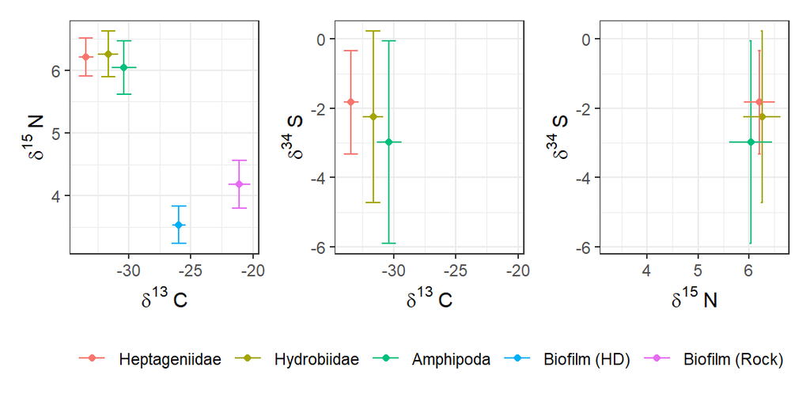

```r
pmCN <- ggplot(datmeans, aes(x=emmean_d13C, y=emmean_d15N, color=Taxon2)) +
  geom_point() +
  geom_errorbar(aes(ymin=lower.CL_d15N, ymax=upper.CL_d15N)) +
  geom_errorbarh(aes(xmin=lower.CL_d13C, xmax=upper.CL_d13C, height=0)) +
  ylab(expression(delta^{15}~N)) +
  xlab(expression(delta^{13}~C))
pmCS <- ggplot(datmeans, aes(x=emmean_d13C, y=emmean_d34S, color=Taxon2)) +
  geom_point() +
  geom_errorbar(aes(ymin=lower.CL_d34S, ymax=upper.CL_d34S)) +
  geom_errorbarh(aes(xmin=lower.CL_d13C, xmax=upper.CL_d13C, height=0)) +
  ylab(expression(delta^{34}~S)) +
  xlab(expression(delta^{13}~C))
pmSN <- ggplot(datmeans, aes(x=emmean_d15N, y=emmean_d34S, color=Taxon2)) +
  geom_point() +
  geom_errorbar(aes(ymin=lower.CL_d34S, ymax=upper.CL_d34S)) +
  geom_errorbarh(aes(xmin=lower.CL_d15N, xmax=upper.CL_d15N, height=0)) +
  ylab(expression(delta^{34}~S)) +
  xlab(expression(delta^{15}~N))
pmCN + pmCS + pmSN + plot_layout(guides="collect") &
  theme_bw() &
  theme(legend.title=element_blank(), legend.position="bottom")
```